# Annual Precipitation Models

Jeffrey D Walker, PhD

August 19, 2014

# Load Data

```r
library(forecast)
library(dplyr)
library(tidyr)
library(lubridate)
library(ggplot2)
theme_set(theme_bw())
library(weatherGen)
data(climate)

# set RNG seed for reproducibility
set.seed(1234)

# compute daily averages across sites
clim.da <- group_by(climate, DATE) %>%
  summarise(N=n(),
            PRCP=mean(PRCP),
            TMIN=mean(TMIN),
            TMAX=mean(TMAX))

# aggregate by water year
clim.wyr <- clim.da %>%
  mutate(WYEAR=wyear(DATE)) %>%
  group_by(WYEAR) %>%
  summarise(N=n(),
            PRCP=sum(PRCP),
            TMIN=mean(TMIN),
            TMAX=mean(TMAX))
```

This figure shows the annual precipitation timeseries.

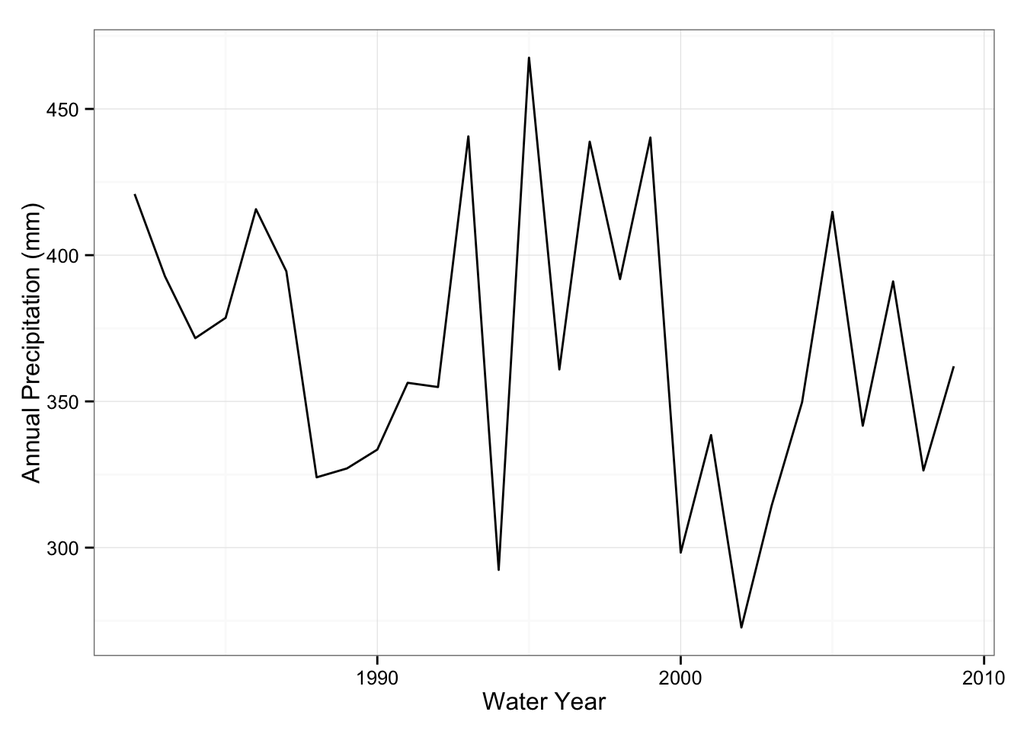

```r
ggplot(clim.wyr, aes(WYEAR, PRCP)) +
  geom_line() +
  labs(x="Water Year", y="Annual Precipitation (mm)")
```

# Scott’s Scripts

## Wavelet Analysis

First, perform the wavelet analysis to identify significant periods using `WAVELET_ANALYSIS()`.

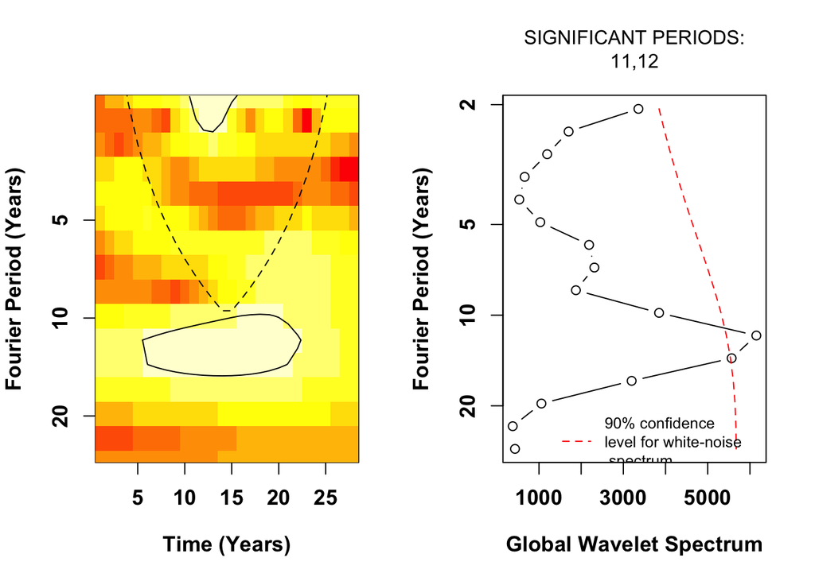

```r
wave <- WAVELET_ANALYSIS(clim.wyr$PRCP, siglvl=0.90,
                         background_noise="white", plot_flag=TRUE)
```

This figure shows that periods 11 and 12 are significant. We then use the `WAVELET_DECOMPOSITION()` function to create a wavelet component that is the sum of these two periods. This function also computes the noise component.

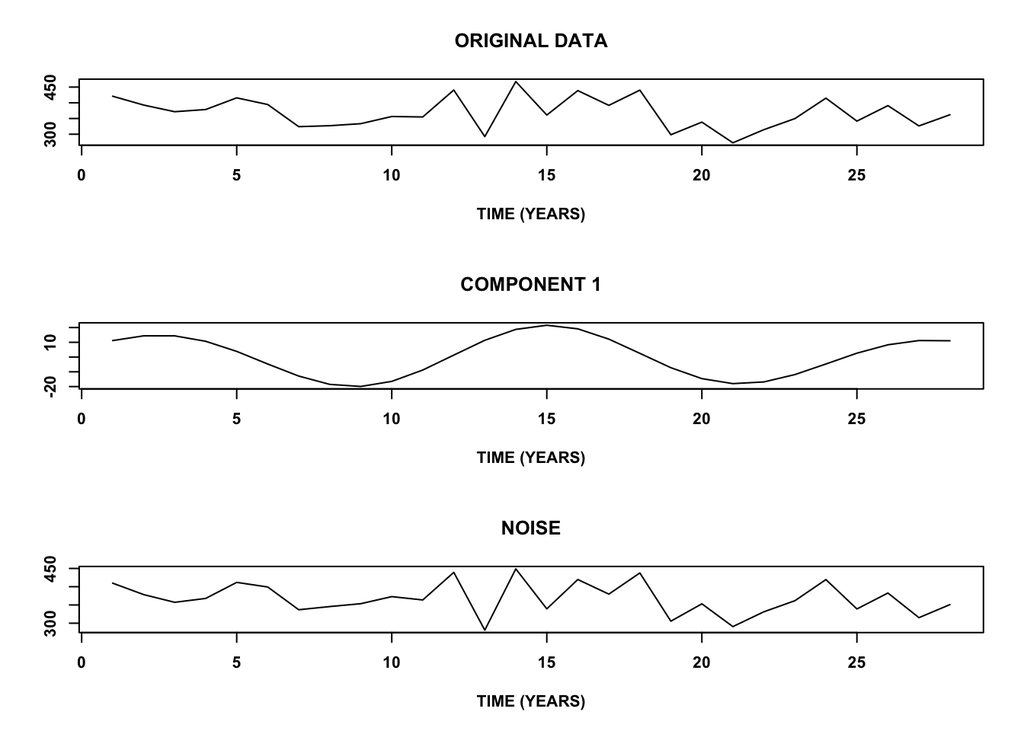

```r
wave.comp <- WAVELET_DECOMPOSITION(CLIMATE_VARIABLE=clim.wyr$PRCP,
                                   NUM_FINAL_PERIODS=1,
                                   ALL_SIG_PERIODS=c(11,12),
                                   NUM_PERIODS_ALL_COMPS=2,
                                   plot_flag=TRUE)
```

```r
head(wave.comp)
```

```
##      NOISE
## [1,] 409.7 11.167
## [2,] 378.4 14.382
## [3,] 357.2 14.369
## [4,] 367.9 10.684
## [5,] 411.9  3.843
## [6,] 399.2 -4.704
```

## Create ARIMA Models

We can then create ARMA models of each wavelet and noise component.

```r
models <- list(NOISE=auto.arima(wave.comp[, 1],
                                max.p=2,max.q=2,max.P=0,max.Q=0,
                                stationary=TRUE),
               COMPONENT=auto.arima(wave.comp[, 2],
                                    max.p=2,max.q=2,max.P=0,max.Q=0,
                                    stationary=TRUE))
models
```

```
## $NOISE
## Series: wave.comp[, 1]
## ARIMA(1,0,1) with non-zero mean
##
## Coefficients:
##          ar1    ma1  intercept
##       -0.924  0.745     367.25
## s.e.   0.095  0.171       6.54
##
## sigma^2 estimated as 1450:  log likelihood=-141.8
## AIC=291.7   AICc=293.4   BIC=297
##
## $COMPONENT
## Series: wave.comp[, 2]
## ARIMA(2,0,0) with zero mean
##
## Coefficients:
##         ar1     ar2
##       1.752  -0.994
## s.e.  0.009   0.006
##
## sigma^2 estimated as 0.246:  log likelihood=-25.29
## AIC=56.57   AICc=57.57   BIC=60.57
```

This figure shows the forecast of each ARMA model (top panel is the noise component, bottom panel is the wavelet component).

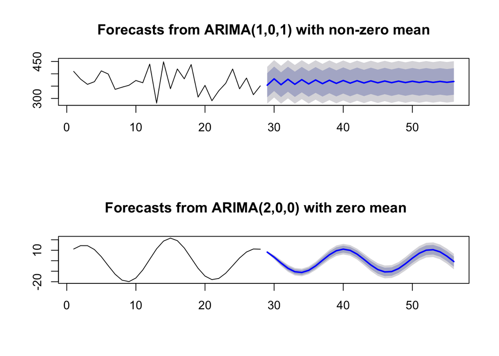

```r
par(mfrow=c(2,1))
plot(forecast(models[["NOISE"]], h=nrow(clim.wyr)))
plot(forecast(models[["COMPONENT"]], h=nrow(clim.wyr)))
```

```r
par(mfrow=c(1,1))
```

We could also simply create an ARMA model of the precipitation timeseries directly, in which case we would not be using the WARM procedure described by Steinschneider and Brown (2013).

```r
ar_models.arima <- list(PRECIP=auto.arima(clim.wyr$PRCP,
                                          max.p=2,max.q=2,max.P=0,max.Q=0,
                                          stationary=TRUE))
ar_models.arima[["PRECIP"]]
```

```
## Series: clim.wyr$PRCP
## ARIMA(0,0,0) with non-zero mean
##
## Coefficients:
##       intercept
##         368.281
## s.e.      9.213
##
## sigma^2 estimated as 2377:  log likelihood=-148.6
## AIC=301.1   AICc=301.6   BIC=303.8
```

Note that this model is a zero order AR and zero order MA, and therefore is simply based on the mean value and thus excludes any low-frequency component.

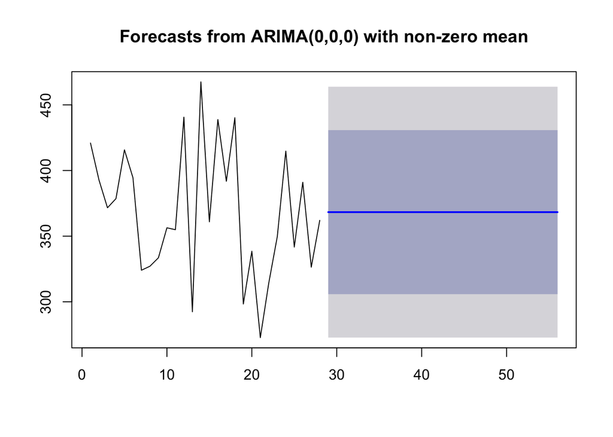

```r
plot(forecast(ar_models.arima[["PRECIP"]], h=nrow(clim.wyr)))
```

## ARIMA Model Simulations

Using the ARMA models of the noise and wavelet components, we can generate forecasts of annual precipitation using the `arima.sim()` function. This function is wrapped in a new function called `simulate.arima()` that simulates a single ARMA model.

```r
simulate.arima <- function(model, n) {
  # simulate one arima model
  sim <- arima.sim(n=n,
                   list(ar=coef(model)[grepl('ar', names(coef(model)))],
                        ma=coef(model)[grepl('ma', names(coef(model)))]),
                   sd = sqrt(model$sigma2[[1]]))

  # extract intercept
  if ('intercept' %in% names(model$coef)) {
    intercept <- model$coef['intercept']
  } else {
    intercept <- 0
  }

  # add intercept (mean) to current simulation
  sim <- sim + intercept

  return(coredata(sim))
}
simulate.arima(model=models[['COMPONENT']], n=40)
```

```
##  [1]  -5.08422  -2.49347   0.05225   2.61562   5.39723   6.87208   6.42099
##  [8]   4.99587   2.13888  -1.33358  -4.03839  -4.86729  -4.92240  -3.89908
## [15]  -1.97208   0.86454   4.23933   7.40689   8.65011   8.25389   5.42853
## [22]   1.03877  -4.17046  -8.88542 -11.12851 -10.30051  -6.87598  -2.18498
## [29]   3.15479   7.10191   8.43580   7.47034   4.49766  -0.01752  -5.49611
## [36]  -9.82275 -11.48191  -9.96182  -5.24766   0.73001
```

Another new function called `simulate.arimas()` then takes a list of models (with each element containing a single wavelet or noise component), performs the individual simulations, and then computes the overall sum. The result is a single simulated timeseries of annual precipitation.

```r
simulate.arimas <- function(models, n, components=TRUE) {
  # n: number of simulation timesteps
  # models: list of arima models
  # components: if TRUE returns list of $sum and $components, otherwise returns just sum vector

  # run simulation on each model and combine into 2-d array
  sim.components <- lapply(models, simulate.arima, n=n) %>% sapply(cbind)

  # compute sum of individual component simulations
  if (ncol(sim.components) > 1) {
    sim.sum <- apply(sim.components, FUN=sum, 1)
  } else {
    sim.sum <- sim.components
  }

  if (components) {
    return(list(components=sim.components, sum=sim.sum))
  } else {
    return(sim.sum)
  }

}
sim.warm <- simulate.arimas(models=models, n=40)
sim.warm
```

```
## $components
##       NOISE COMPONENT
##  [1,] 369.2  -1.88381
##  [2,] 415.7  -3.55053
##  [3,] 403.2  -3.16964
##  [4,] 320.2  -2.49704
##  [5,] 387.0  -0.93000
##  [6,] 340.5   1.45327
##  [7,] 372.2   2.85133
##  [8,] 351.7   2.83021
##  [9,] 334.2   1.65726
## [10,] 401.8  -0.61505
## [11,] 327.3  -2.60487
## [12,] 396.8  -3.61858
## [13,] 285.4  -4.27382
```

[output cut: 33 more lines]

Here is a plot of the resulting simulated annual precipitation timeseries.

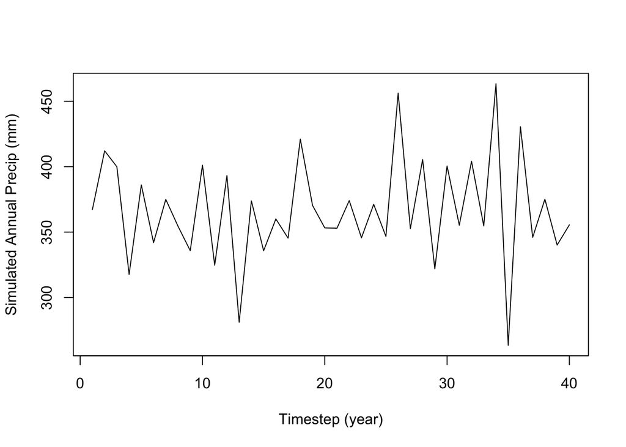

```r
plot(sim.warm$sum, type='l', xlab='Timestep (year)', ylab='Simulated Annual Precip (mm)')
```

We then perform a wavelet analysis of the simulated precipitation to compare the GWS of the observed timeseries with that of the simulated timeseries.

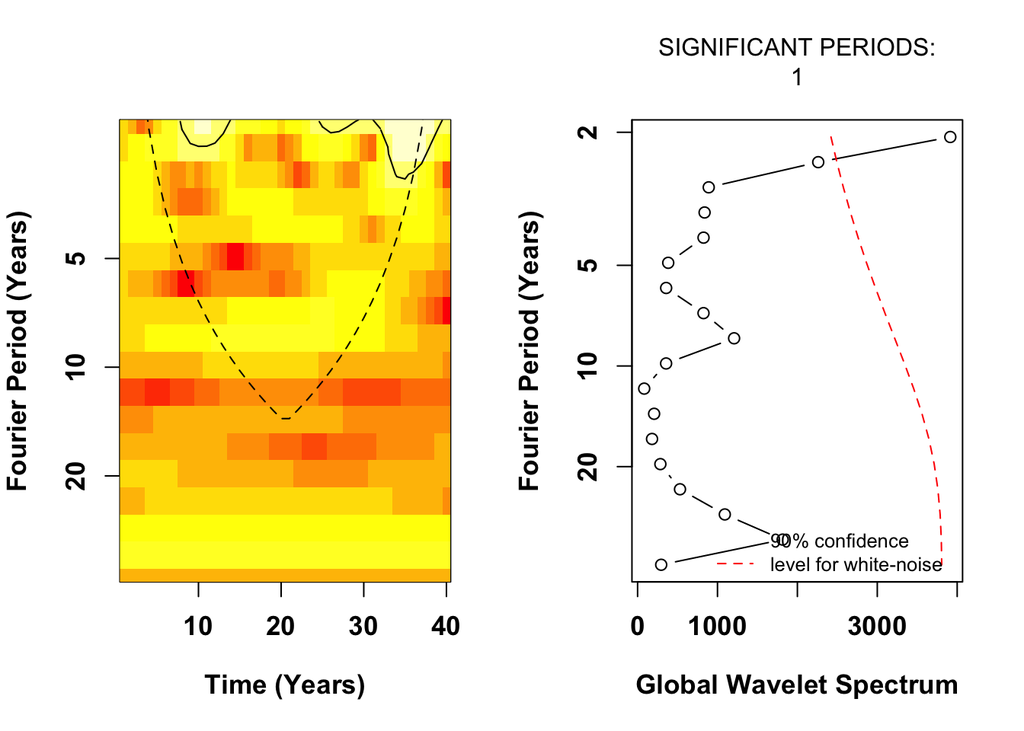

```r
wt.sim.warm <- WAVELET_ANALYSIS(sim.warm$sum, siglvl=0.90,
                                background_noise="white", plot_flag=TRUE)
```

Next, we repeat this procedure through a Monte Carlo simulation by generating `n.iter` simulation timeseries. Based on this set of simulations, we can compute some statistics on the simulation GWS power to compare against the GWS power of the observed timeseries.

```r
n.iter <- 100
n.sim <- 40

sim.warm.prcp <- array(NA, c(n.sim, n.iter))
sim.warm.gws <- array(NA, c(length(wt.sim.warm[[1]]), n.iter))
for (i in 1:n.iter) {
  i.sim.warm <- simulate.arimas(models=models, n=40)
  i.wt <- WAVELET_ANALYSIS(i.sim.warm$sum, siglvl=0.90,
                           background_noise="white", plot_flag=FALSE)
  sim.warm.prcp[,i] <- i.sim.warm$sum
  sim.warm.gws[,i] <- i.wt[[1]]
}

sim.warm.prcp.stat <- cbind(MEAN=rowMeans(sim.warm.prcp),
                            Q025=apply(sim.warm.prcp, 1, quantile, 0.025),
                            Q975=apply(sim.warm.prcp, 1, quantile, 0.975))

sim.warm.gws.stat <- cbind(MEAN=rowMeans(sim.warm.gws),
                           Q025=apply(sim.warm.gws, 1, quantile, 0.025),
                           Q975=apply(sim.warm.gws, 1, quantile, 0.975))
```

This plot shows the mean across the simulation timeseries, with the shaded region representing the 2.5 and 97.5 percent quantiles.

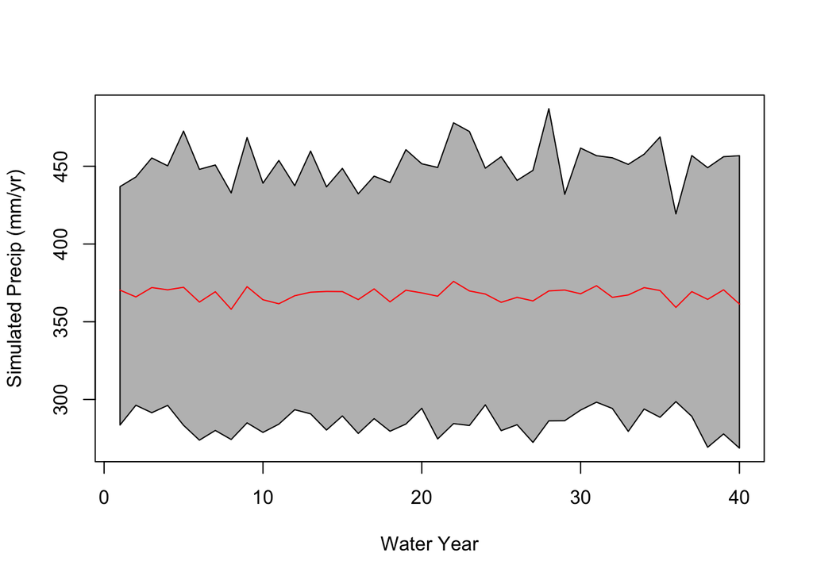

```r
par(mfrow=c(1,1))
plot(sim.warm.prcp.stat[, 'MEAN'], type='n',
     xlab="Water Year", ylab="Simulated Precip (mm/yr)",
     ylim=range(sim.warm.prcp.stat))
polygon(c(seq(1, nrow(sim.warm.prcp.stat)),
          rev(seq(1, nrow(sim.warm.prcp.stat)))),
        c(sim.warm.prcp.stat[, 'Q025'],
          rev(sim.warm.prcp.stat[, 'Q975'])),col="grey")
lines(sim.warm.prcp.stat[, 'MEAN'], col='red')
```

This figure shows each individual simulated timeseries (the red line is the overall mean).

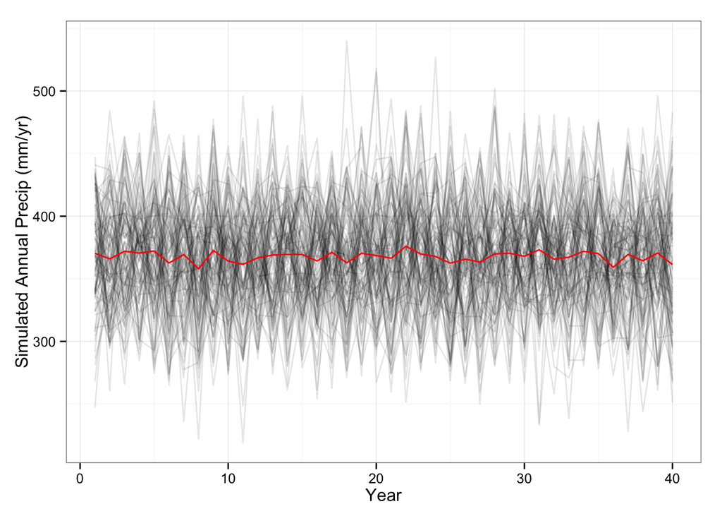

```r
as.data.frame(sim.warm.prcp) %>%
  mutate(YEAR=seq(1:nrow(sim.warm.prcp))) %>%
  gather(TRIAL, VALUE, -YEAR) %>%
  ggplot(aes(YEAR, VALUE)) +
  geom_line(aes(group=TRIAL), alpha=0.1) +
  stat_summary(fun.y=mean, geom='line', color='red') +
  labs(x='Year', y="Simulated Annual Precip (mm/yr)")
```

This figure summarises the spectrum power for each period, and compares the mean, standard deviation and skew of the simulated (blue) and observed (red) annual timeseries.

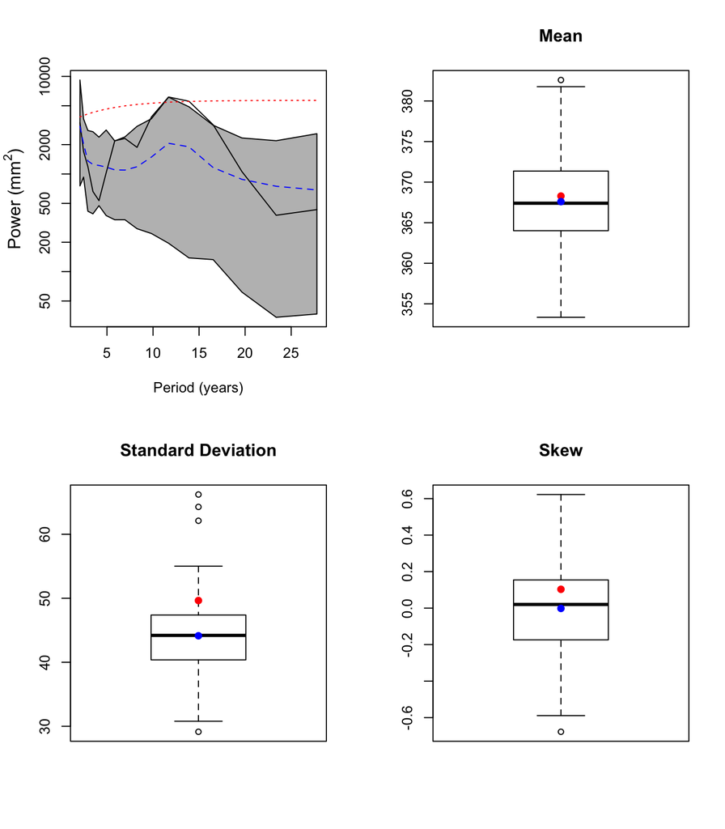

```r
par(mfrow=c(2,2))
x1 <- 1
x2 <- length(wave[[3]])
ymin <- min(wave[[1]], wave[[2]],
            sim.warm.gws.stat[x1:x2, 'MEAN'],
            sim.warm.gws.stat[x1:x2, 'Q025'])
ymax <- max(wave[[1]], wave[[2]],
            sim.warm.gws.stat[x1:x2, 'MEAN'],
            sim.warm.gws.stat[x1:x2, 'Q975'])
plot(wave[[3]], wave[[1]],
     type="n", ylim=c(ymin,ymax), xlab="Period (years)", ylab="",
     main="", log="y")
mtext(side=2, expression(paste("Power (",mm^2,")")), line=2.5)
polygon(c(wave[[3]],
          rev(wave[[3]])),
        c(sim.warm.gws.stat[x1:x2, 'Q025'],
          rev(sim.warm.gws.stat[x1:x2, 'Q975'])),
        col="grey")
lines(wave[[3]], wave[[1]])
lines(wave[[3]], sim.warm.gws.stat[x1:x2, 'MEAN'], lty=2, col="blue")
lines(wave[[3]], wave[[2]], col="red", lty=3)

boxplot(colMeans(sim.warm.prcp), main="Mean")
points(mean(clim.wyr$PRCP),col="red",pch=19)
points(mean(colMeans(sim.warm.prcp)), col="blue", pch=19)

boxplot(apply(sim.warm.prcp, 2, sd), main="Standard Deviation")
points(sd(clim.wyr$PRCP), col="red", pch=19)
points(mean(apply(sim.warm.prcp, 2, sd)), col="blue", pch=19)

boxplot(apply(sim.warm.prcp, 2, skewness), main="Skew")
points(skewness(clim.wyr$PRCP), col="red", pch=19)
points(mean(apply(sim.warm.prcp, 2, skewness)),col="blue",pch=19)
```

The figure above shows the distributions of power, mean, standard deviation and skewness for the monte carlo simulations of the arima models. The GWS power for the historical data is the black line, the mean GWS power for the arima models is the blue line, and the significance thresholds is the red line. The shaded area is the 2.5-97.5% confidence interval of the simulated GWS power.

The boxplots are the distributions of the three statistics for the monte carlo simulations, the red dot is the statistic of the historical timeseries, and the blue dot is the mean statistic for the simulated timeseries.

## Adjust Annual ARIMA Models

The ARMA models of the noise and wavelet components can be adjusted by changing one of the following parameters (see Table 1, Steinschneider and Brown, 2013):

1. lag1 coefficients of the AR model ($\alpha_h$) to adjust the persistence of the low-frequency signals
2. standard deviation of the noise component ($\sigma_e$) to adjust the magnitude of the low-frequency signals

This process uses the `hydromad::sceOptim()` function. Scott originally copied this function into his code, but I’ll use the `hydromad` package instead.

Using Scott’s `Adjust_WARM_Model()` function, we can change the noise component based on these two factors. The following `adjust.noise.model()` function modifies the coefficients of the noise component ARMA model and returns the updated and complete list of ARMA models.

```r
adjust.noise.model <- function(models, lag1.factor, sd.factor) {
  # lag1.factor - multiplicative adjustment factor for lag1 arma coefficients
  # sd.factor - multiplicative adjustment factor for noise standard deviation
  # models - list of arma models generated by WAVELET_DECOMPOSITION()

  # extract noise model and coefficients
  noise <- models[[1]]
  noise.e_var<- noise$sigma2
  noise.ar <- coef(noise)[grepl('ar', names(coef(noise)))]
  noise.ma <- coef(noise)[grepl('ma', names(coef(noise)))]

  # extract component models and coefficients
  comps.e_var <- list()
  comps.ar <- list()
  comps.ma <- list()
  for (l in 2:dim(wave.comp)[2]) {
    comp <- models[[l]]
    comps.e_var[[l-1]] <- comp$sigma2
    comps.ar[[l-1]] <- coef(comp)[grepl('ar', names(coef(comp)))]
    comps.ma[[l-1]] <- coef(comp)[grepl('ma', names(coef(comp)))]
  }

  new_parameters <- Adjust_WARM_Model(sd.factor, lag1.factor,
                                      noise.e_var, noise.ar, noise.ma,
                                      comps.e_var, comps.ar, comps.ma)

  noise.model.adj <- models[['NOISE']]
  noise.model.adj$sigma2 <- new_parameters[[1]]
  non_intercept <- which(names(models[['NOISE']]$coef)!="intercept")
  if (length(non_intercept)>0) {
    for (cur_par in 1:length(non_intercept)) {
      noise.model.adj$coef[[cur_par]] <- new_parameters[[cur_par+1]]
    }
  }
  models[['NOISE']] <- noise.model.adj
  return(models)
}
adjust.noise.model(models=models, lag1.factor=1, sd.factor=1)
```

```
## $NOISE
## Series: wave.comp[, 1]
## ARIMA(1,0,1) with non-zero mean
##
## Coefficients:
##          ar1    ma1  intercept
##       -0.924  0.745     367.25
## s.e.   0.095  0.171       6.54
##
## sigma^2 estimated as 1450:  log likelihood=-141.8
## AIC=291.7   AICc=293.4   BIC=297
##
## $COMPONENT
## Series: wave.comp[, 2]
## ARIMA(2,0,0) with zero mean
##
## Coefficients:
##         ar1     ar2
##       1.752  -0.994
## s.e.  0.009   0.006
##
## sigma^2 estimated as 0.246:  log likelihood=-25.29
## AIC=56.57   AICc=57.57   BIC=60.57
```

If `lag1.factor=1` and `sd.factor=1`, then there are no adjustments. For reference, here are the original ARMA models, which have the same coefficients as those shown above.

```r
models
```

```
## $NOISE
## Series: wave.comp[, 1]
## ARIMA(1,0,1) with non-zero mean
##
## Coefficients:
##          ar1    ma1  intercept
##       -0.924  0.745     367.25
## s.e.   0.095  0.171       6.54
##
## sigma^2 estimated as 1450:  log likelihood=-141.8
## AIC=291.7   AICc=293.4   BIC=297
##
## $COMPONENT
## Series: wave.comp[, 2]
## ARIMA(2,0,0) with zero mean
##
## Coefficients:
##         ar1     ar2
##       1.752  -0.994
## s.e.  0.009   0.006
##
## sigma^2 estimated as 0.246:  log likelihood=-25.29
## AIC=56.57   AICc=57.57   BIC=60.57
```

We can now use this function to compare the effects of changing the lag1 and sd factors in the ARMA model for the noise component. These figures show the forecasts of the noise model only using the `forecast::forecast()` function. It shows that reducing the noise sd results in less variability. And changing the lag1 coefficient does not seem to have much effect.

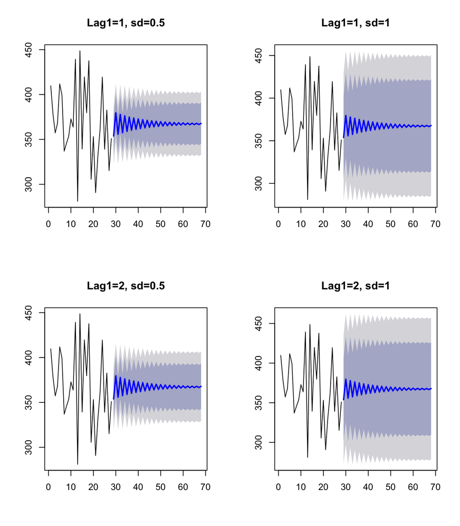

```r
par(mfrow=c(2,2))
adjust.noise.model(models=models, lag1.factor=1, sd.factor=0.5)[['NOISE']] %>%
  forecast(h=40) %>%
  plot(main="Lag1=1, sd=0.5")
adjust.noise.model(models=models, lag1.factor=1, sd.factor=1)[['NOISE']] %>%
  forecast(h=40) %>%
  plot(main="Lag1=1, sd=1")
adjust.noise.model(models=models, lag1.factor=0.5, sd.factor=0.5)[['NOISE']] %>%
  forecast(h=40) %>%
  plot(main="Lag1=2, sd=0.5")
adjust.noise.model(models=models, lag1.factor=0.5, sd.factor=1)[['NOISE']] %>%
  forecast(h=40) %>%
  plot(main="Lag1=2, sd=1")
```

# weatherGen Package

We can repeat the same analysis using the `weatherGen` package.

## Wavelet Analysis

First, perform the wavelet analysis.

```r
wgen_wave <- weatherGen::wavelet_analysis(clim.wyr$PRCP, sig.level=0.90,
                                          noise.type='white')
```

Then reconstruct the wavelet components.

```r
wgen_wave.comp <- weatherGen::wavelet_components(x=clim.wyr$PRCP,
                                                 wt=wgen_wave,
                                                 n.periods=1,
                                                 sig.periods=c(11,12),
                                                 n.comp.periods=2)
```

## Create ARIMA Models

Now create the arima models.

```r
wgen_models <- weatherGen::arima_models(components=wgen_wave.comp)
```

Here is a plot of the forecasts for each component arima model (top panel is the noise component, bottom panel is the wavelet component).

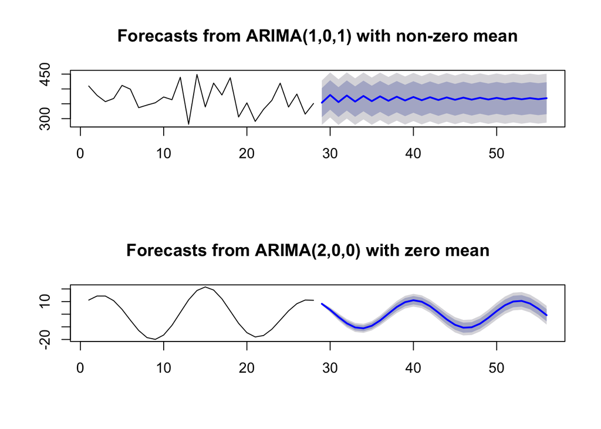

```r
par(mfrow=c(2,1))
plot(forecast(wgen_models[["NOISE"]], h=nrow(clim.wyr)))
plot(forecast(wgen_models[["COMPONENT 1"]], h=nrow(clim.wyr)))
```

```r
par(mfrow=c(1,1))
```

## ARIMA Model Simulations

Simulations for each ARIMA models are generated using the `weatherGen::simulate.arima()` function.

```r
weatherGen::simulate_arima(model=wgen_models[['COMPONENT 1']], n=40)
```

```
##  [1] -6.53280 -5.45031 -2.87424 -0.38489  2.27118  4.33370  5.10280
##  [8]  4.82251  3.41943  1.11578 -1.26570 -3.07726 -5.09670 -5.23724
## [15] -4.44732 -2.33495  0.27310  2.64847  4.26623  4.33075  3.59911
## [22]  2.60035  1.08188 -0.02914 -1.49886 -1.72709 -1.72650 -1.65183
## [29] -1.47517 -1.25052 -0.38987  1.85596  4.52847  5.89615  5.22821
## [36]  3.39801  1.43524 -0.64770 -3.04168 -5.20609
```

And the `weatherGen::simulate.arimas()` function can then be used to simulate a list of arima models containing multiple components (noise and wavelet).

```r
wgen_sim.warm <- weatherGen::simulate_arimas(models=wgen_models, n=40)
wgen_sim.warm
```

```
## $components
##       NOISE COMPONENT 1
##  [1,] 435.7      3.0976
##  [2,] 291.0      6.3698
##  [3,] 363.1      8.3735
##  [4,] 284.8      7.8107
##  [5,] 427.9      5.5745
##  [6,] 276.4      2.8419
##  [7,] 367.5     -0.4126
##  [8,] 404.5     -4.2833
##  [9,] 348.0     -6.9646
## [10,] 350.5     -8.0714
## [11,] 388.4     -7.3727
## [12,] 319.9     -5.1544
## [13,] 416.3     -1.1364
```

[output cut: 33 more lines]

Here is a plot of the resulting simulated annual precipitation timeseries.

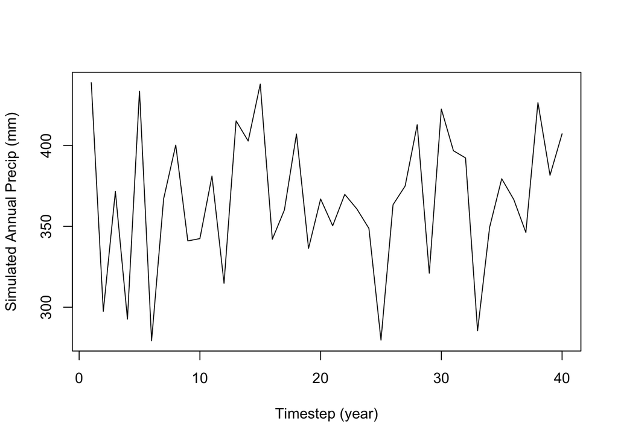

```r
plot(wgen_sim.warm$sum, type='l', xlab='Timestep (year)', ylab='Simulated Annual Precip (mm)')
```

We can then perform a wavelet analysis of the simulated precipitation to compare the GWS of the observed timeseries with that of the simulated timeseries.

```r
wgen_wt.sim.warm <- weatherGen::wavelet_analysis(wgen_sim.warm$sum, sig.level=0.90,
                                                 noise.type='white')
```

Finally, we can use the `weatherGen::mc_arima()` function to perform a Monte Carlo simulation by repeating this procedure multiple times.

```r
wgen_mc <- weatherGen::mc_arimas(models=wgen_models, n=40, n.iter=100)
str(wgen_mc)
```

```
## List of 4
##  $ x       : num [1:40, 1:100] 335 407 371 416 383 ...
##  $ gws     : num [1:18, 1:100] 1610 1264 862 1027 1177 ...
##  $ x.stat  : num [1:40, 1:3] 365 373 372 376 366 ...
##   ..- attr(*, "dimnames")=List of 2
##   .. ..$ : NULL
##   .. ..$ : chr [1:3] "MEAN" "Q025" "Q975"
##  $ gws.stat: num [1:18, 1:3] 2844 1856 1206 1195 1235 ...
##   ..- attr(*, "dimnames")=List of 2
##   .. ..$ : NULL
##   .. ..$ : chr [1:3] "MEAN" "Q025" "Q975"
```

This plot shows the mean across the simulation timeseries, with the shaded region representing the 2.5 and 97.5 percent quantiles.

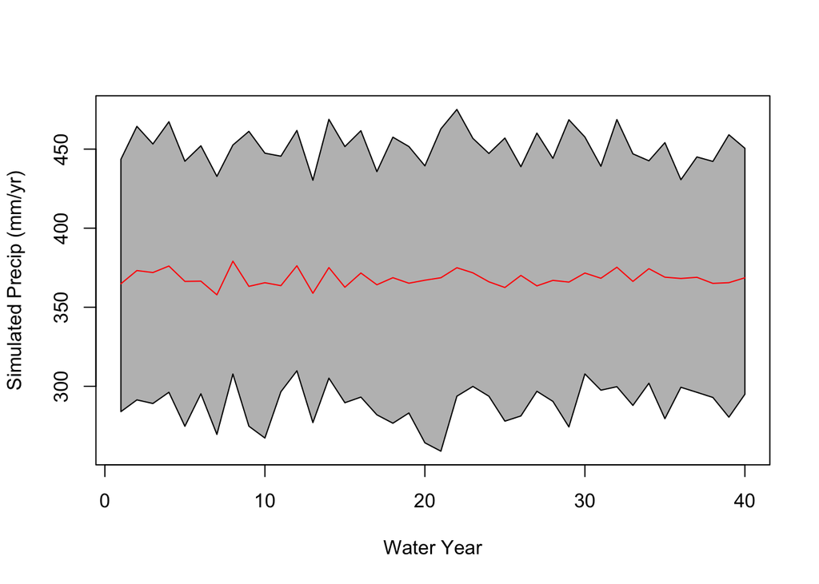

```r
par(mfrow=c(1,1))
plot(wgen_mc$x.stat[, 'MEAN'], type='n',
     xlab="Water Year", ylab="Simulated Precip (mm/yr)",
     ylim=range(wgen_mc$x.stat))
polygon(c(seq(1, nrow(wgen_mc$x.stat)),
          rev(seq(1, nrow(wgen_mc$x.stat)))),
        c(wgen_mc$x.stat[, 'Q025'],
          rev(wgen_mc$x.stat[, 'Q975'])),col="grey")
lines(wgen_mc$x.stat[, 'MEAN'], col='red')
```

This figure shows each individual simulated timeseries (the red line is the overall mean).

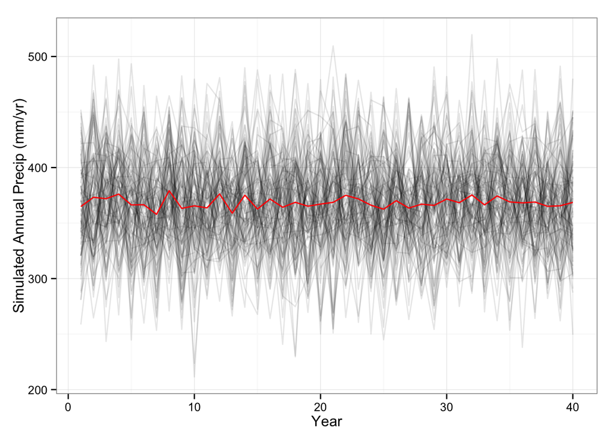

```r
as.data.frame(wgen_mc$x) %>%
  mutate(YEAR=seq(1:nrow(wgen_mc$x))) %>%
  gather(TRIAL, VALUE, -YEAR) %>%
  ggplot(aes(YEAR, VALUE)) +
  geom_line(aes(group=TRIAL), alpha=0.1) +
  stat_summary(fun.y=mean, geom='line', color='red') +
  labs(x='Year', y="Simulated Annual Precip (mm/yr)")
```

This figure summarises the spectrum power for each period, and compares the mean, standard deviation and skew of the simulated (blue) and observed (red) annual timeseries.

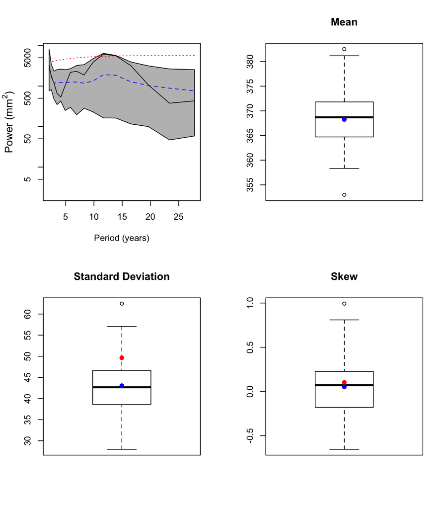

```r
par(mfrow=c(2,2))
x1 <- 1
x2 <- length(wgen_wave$period)
ymin <- min(wgen_wave$period, wgen_wave$gws,
            wgen_mc$gws.stat[x1:x2, 'MEAN'],
            wgen_mc$gws.stat[x1:x2, 'Q025'])
ymax <- max(wgen_wave$period, wgen_wave$gws,
            wgen_mc$gws.stat[x1:x2, 'MEAN'],
            wgen_mc$gws.stat[x1:x2, 'Q975'])
plot(wgen_wave$period, wgen_wave$gws,
     type="n", ylim=c(ymin,ymax), xlab="Period (years)", ylab="",
     main="", log="y")
mtext(side=2, expression(paste("Power (",mm^2,")")), line=2.5)
polygon(c(wgen_wave$period,
          rev(wgen_wave$period)),
        c(wgen_mc$gws.stat[x1:x2, 'Q025'],
          rev(wgen_mc$gws.stat[x1:x2, 'Q975'])),
        col="grey")
lines(wgen_wave$period, wgen_wave$gws)
lines(wgen_wave$period, wgen_mc$gws.stat[x1:x2, 'MEAN'], lty=2, col="blue")
lines(wgen_wave$period, wgen_wave$gws.sig$signif, col="red", lty=3)

boxplot(colMeans(wgen_mc$x), main="Mean")
points(mean(clim.wyr$PRCP),col="red",pch=19)
points(mean(colMeans(wgen_mc$x)), col="blue", pch=19)

boxplot(apply(wgen_mc$x, 2, sd), main="Standard Deviation")
points(sd(clim.wyr$PRCP), col="red", pch=19)
points(mean(apply(wgen_mc$x, 2, sd)), col="blue", pch=19)

boxplot(apply(wgen_mc$x, 2, skewness), main="Skew")
points(skewness(clim.wyr$PRCP), col="red", pch=19)
points(mean(apply(wgen_mc$x, 2, skewness)),col="blue",pch=19)
```

The figure above shows the distributions of power, mean, standard deviation and skewness for the monte carlo simulations of the arima models. The GWS power for the historical data is the black line, the mean GWS power for the arima models is the blue line, and the significance thresholds is the red line. The shaded area is the 2.5-97.5% confidence interval of the simulated GWS power.

The boxplots are the distributions of the three statistics for the monte carlo simulations, the red dot is the statistic of the historical timeseries, and the blue dot is the mean statistic for the simulated timeseries.